# PBA AS1 Answer Sheet

### **PART I:**

### **Question 1 (2 points)**

Locate the directory path where the dataset is stored, load it into R, and take a look at the data.

**Rubric**: 1 point for locating the directory and loading the data; 1 point for verifying the dataset’s dimensions using `head()` and `str()` functions.

### Solution:

```r
raw <- read.csv(url("https://bit.ly/3jenBeO"))
str(raw) # Print the structure of the data set.
```

```
## 'data.frame':    541909 obs. of  8 variables:
##  $ InvoiceNo  : chr  "536365" "536365" "536365" "536365" ...
##  $ StockCode  : chr  "85123A" "71053" "84406B" "84029G" ...
##  $ Description: chr  "WHITE HANGING HEART T-LIGHT HOLDER" "WHITE METAL LANTERN" "CREAM CUPID HEARTS COAT HANGER" "KNITTED UNION FLAG HOT WATER BOTTLE" ...
##  $ Quantity   : int  6 6 8 6 6 2 6 6 6 32 ...
##  $ InvoiceDate: chr  "12/1/10 8:26" "12/1/10 8:26" "12/1/10 8:26" "12/1/10 8:26" ...
##  $ UnitPrice  : num  2.55 3.39 2.75 3.39 3.39 7.65 4.25 1.85 1.85 1.69 ...
##  $ CustomerID : int  17850 17850 17850 17850 17850 17850 17850 17850 17850 13047 ...
##  $ Country    : chr  "United Kingdom" "United Kingdom" "United Kingdom" "United Kingdom" ...
```

```r
head(raw) # Print the first 6 observations in the data set.
```

```
##   InvoiceNo StockCode                         Description Quantity  InvoiceDate
## 1    536365    85123A  WHITE HANGING HEART T-LIGHT HOLDER        6 12/1/10 8:26
## 2    536365     71053                 WHITE METAL LANTERN        6 12/1/10 8:26
## 3    536365    84406B      CREAM CUPID HEARTS COAT HANGER        8 12/1/10 8:26
## 4    536365    84029G KNITTED UNION FLAG HOT WATER BOTTLE        6 12/1/10 8:26
## 5    536365    84029E      RED WOOLLY HOTTIE WHITE HEART.        6 12/1/10 8:26
## 6    536365     22752        SET 7 BABUSHKA NESTING BOXES        2 12/1/10 8:26
##   UnitPrice CustomerID        Country
## 1      2.55      17850 United Kingdom
## 2      3.39      17850 United Kingdom
## 3      2.75      17850 United Kingdom
## 4      3.39      17850 United Kingdom
## 5      3.39      17850 United Kingdom
## 6      7.65      17850 United Kingdom
```

### **Question 2 (3 points)**

Convert the `InvoiceDate` to date class and filter the data to include only transactions from July to August 2011. Use this filtered dataset for all subsequent questions in Part I.

**Rubric**: 1 points for converting `InvoiceDate` to date class; 2 points for correctly filtering the data and verifying the number of unique `InvoiceNo` entries.

### Solution:

We will be using data from 2011/07 to 2011/08. Convert InvoiceDate to date class and subset the data. You should see 3,664 unique transactions (i.e., InvoiceNo) left in the data. One alternative is to read the data from just those dates rather than reading in the entire dataset and subsetting to those dates.

- You can use length() and unique() functions on InvoiceNo to find out the number of unique transactions.
- You may find it useful to convert the Date and Time variables to Date/Time classes in R using the strptime() and as.Date() functions. lubridate package can also be used which will be helpful for more complex date operations.

```r
# Convert InvoiceDate to a Date Object
raw$date <- as.Date(raw$InvoiceDate, format = "%m/%d/%y")
data <- subset(raw, subset = raw$date >= as.Date("2011/07/01") &
                 raw$date <= as.Date("2011/08/31"))
str(data)
```

```
## 'data.frame':    74802 obs. of  9 variables:
##  $ InvoiceNo  : chr  "558638" "558638" "558638" "558638" ...
##  $ StockCode  : chr  "84836" "71459" "22784" "23145" ...
##  $ Description: chr  "ZINC METAL HEART DECORATION" "HANGING JAM JAR T-LIGHT HOLDER" "LANTERN CREAM GAZEBO " "ZINC T-LIGHT HOLDER STAR LARGE" ...
##  $ Quantity   : int  12 24 3 12 12 12 6 4 18 12 ...
##  $ InvoiceDate: chr  "7/1/11 8:16" "7/1/11 8:16" "7/1/11 8:16" "7/1/11 8:16" ...
##  $ UnitPrice  : num  1.25 0.85 4.95 0.95 1.25 2.08 2.95 3.75 1.65 1.25 ...
##  $ CustomerID : int  16317 16317 16317 16317 16317 16317 16317 16317 16317 16317 ...
##  $ Country    : chr  "United Kingdom" "United Kingdom" "United Kingdom" "United Kingdom" ...
##  $ date       : Date, format: "2011-07-01" "2011-07-01" ...
```

```r
summary(data$date)
```

```
##         Min.      1st Qu.       Median         Mean      3rd Qu.         Max.
## "2011-07-01" "2011-07-14" "2011-07-29" "2011-07-30" "2011-08-16" "2011-08-31"
```

```r
length(unique(data$InvoiceNo)) # 3,664: Print the number of transactions made in Jul & Aug of 2011.
```

```
## [1] 3664
```

```r
library(lubridate)
head(floor_date(mdy_hm(raw$InvoiceDate), unit = "day")) # Lubridate package offers convenient fns. like mdy_hm() and floor_date().
```

```
## [1] "2010-12-01 UTC" "2010-12-01 UTC" "2010-12-01 UTC" "2010-12-01 UTC"
## [5] "2010-12-01 UTC" "2010-12-01 UTC"
```

### **Question 3 (6 points)**

Perform basic data analysis on the dataset by completing the following tasks:

**Tasks**:

1. Compute the mean of `Quantity` and `UnitPrice`.
2. Determine the data types of each column.
3. Compute the number of unique values in each column.

**Rubric**: 2 points for each task.

### Solution:

```r
head(data)
```

```
##        InvoiceNo StockCode                      Description Quantity
## 245904    558638     84836      ZINC METAL HEART DECORATION       12
## 245905    558638     71459   HANGING JAM JAR T-LIGHT HOLDER       24
## 245906    558638     22784            LANTERN CREAM GAZEBO         3
## 245907    558638     23145   ZINC T-LIGHT HOLDER STAR LARGE       12
## 245908    558638     22674    FRENCH TOILET SIGN BLUE METAL       12
## 245909    558638     21174 POTTERING IN THE SHED METAL SIGN       12
##        InvoiceDate UnitPrice CustomerID        Country       date
## 245904 7/1/11 8:16      1.25      16317 United Kingdom 2011-07-01
## 245905 7/1/11 8:16      0.85      16317 United Kingdom 2011-07-01
## 245906 7/1/11 8:16      4.95      16317 United Kingdom 2011-07-01
## 245907 7/1/11 8:16      0.95      16317 United Kingdom 2011-07-01
## 245908 7/1/11 8:16      1.25      16317 United Kingdom 2011-07-01
## 245909 7/1/11 8:16      2.08      16317 United Kingdom 2011-07-01
```

```r
# 1) Compute the mean of Quantity and UnitPrice
mean_values <- colMeans(data[, c(4,6)], na.rm = TRUE); mean_values
```

```
##  Quantity UnitPrice
## 10.659006  4.308608
```

```r
# 2) Determine the types of each column
column_types <- lapply(data, class); column_types
```

```
## $InvoiceNo
## [1] "character"
##
## $StockCode
## [1] "character"
##
## $Description
## [1] "character"
##
## $Quantity
## [1] "integer"
##
## $InvoiceDate
## [1] "character"
##
## $UnitPrice
## [1] "numeric"
##
## $CustomerID
## [1] "integer"
##
## $Country
## [1] "character"
##
## $date
## [1] "Date"
```

```r
# Using lapply to count the number of unique values for each column
unique_counts <- lapply(data, function(x) length(unique(x))); unique_counts
```

```
## $InvoiceNo
## [1] 3664
##
## $StockCode
## [1] 2982
##
## $Description
## [1] 2953
##
## $Quantity
## [1] 287
##
## $InvoiceDate
## [1] 3343
##
## $UnitPrice
## [1] 447
##
## $CustomerID
## [1] 1541
##
## $Country
## [1] 28
##
## $date
## [1] 52
```

### **Question 4 (6 points)**

Conduct a country-specific analysis on the dataset.

**Tasks**:

1. Subset the data for transactions in the U.K., Netherlands, and Australia then perform the following analyses separately for each country.
2. Report the average and standard deviation of `UnitPrice` for each country.
3. Report the number of unique transactions and customers in these countries.

**Rubric**: 2 points for each task.

### Solution:

```r
# 1) Subset the data for transactions in the U.K., Netherlands, and Australia then perform the following analyses separately for each country.
UK <- subset(x = data, subset = Country == "United Kingdom")
Netherlands <- subset(x = data, subset = Country == "Netherlands")
Australia <- subset(x = data, subset = Country == "Australia")

subdata <- list(UK = UK,
                Netherlands = Netherlands,
                Australia = Australia)

# 2) Report the average and standard deviation of UnitPrice for each country.
calc_stats <- function(df) {
  c(Mean = mean(df$UnitPrice, na.rm = TRUE),
    SD = sd(df$UnitPrice, na.rm = TRUE))
}
stats_subdata <- lapply(subdata, calc_stats); stats_subdata
```

```
## $UK
##      Mean        SD
##  4.359879 99.412295
##
## $Netherlands
##      Mean        SD
##  2.862109 12.206784
##
## $Australia
##     Mean       SD
## 2.379290 2.032917
```

```r
# 3) Report the number of unique transactions and customers in these countries.
count_uniques <- function(df) {
  c(NumTransactions = length(unique(df$InvoiceNo)),
    NumCustomers = length(unique(df$CustomerID)))
}

# Apply the function to each subset in the list
Num_subdata <- lapply(subdata, count_uniques); Num_subdata
```

```
## $UK
## NumTransactions    NumCustomers
##            3310            1376
##
## $Netherlands
## NumTransactions    NumCustomers
##              11               1
##
## $Australia
## NumTransactions    NumCustomers
##              11               3
```

### **Question 5 (5 points)**

Identify and count customers who made a refund.

**Rubric**: 3 points for identifying customers who made a refund; 2 points for counting the number of such customers and storing their IDs in a vector called `cust_refund`.

### Solution:

Do we see any customers who made a refund? **Yes**

How many customers made a refund (make sure to exclude the observations without the CustomerID)? Assign the IDs of the customers who made at least one refund during the period into a vector called cust_refund.

```r
refunds <- subset(x = data, subset = substr(data$InvoiceNo,1,1) == "C")
refunds <- subset(refunds, !is.na(CustomerID))
cust_refund <- unique(refunds$CustomerID); cust_refund
```

```
##   [1] 16746 17338 17888 12901 16422 12709 16498 16700 18075 16570 14415 15033
##  [13] 15023 17841 13767 17063 13763 12619 14952 14338 18171 13115 13826 16729
##  [25] 13089 13534 15518 17017 14034 13021 16571 15985 17389 12494 13338 16393
##  [37] 17511 13420 17469 12507 12626 12379 12980 12472 17861 13510 17719 16581
##  [49] 17837 13984 18072 16550 13408 14680 13078 14905 15615 13769 13047 14267
##  [61] 15078 14016 14808 17126 16283 18024 13627 14690 13184 14796 17706 18142
##  [73] 14389 13267 16033 13745 12717 17337 15719 18193 17381 13013 13599 15416
##  [85] 17069 16701 13743 14483 16998 15493 16156 14088 14426 14562 17696 13815
##  [97] 14527 16656 14258 16779 17049 16782 17440 15769 17652 17068 12451 14572
## [109] 14659 16398 14159 15527 14390 17448 12930 15125 18087 13564 16717 17809
## [121] 15369 13154 17603 12705 16401 16488 12415 12971 12921 16145 17738 17651
## [133] 14911 12468 17065 14437 13941 15249 16271 17866 15802 18102 17581 16255
## [145] 14606 13217 15298 16013 17811 13488 14410 13668 12830 17677 16859 15152
## [157] 12722 15260 17593 18198 14875 13468 16875 13590 14733 14400 15005 14056
## [169] 17612 13098 16705 13050 14916 15187 15708 13802 13097 13230 12576 13520
```

[output cut: 17 more lines]

```r
length(cust_refund) # Print the number of customers who made at least one refund.
```

```
## [1] 381
```

### **Question 6 (5 points)**

Some customers made purchases without logging into the e-commerce site. This would create records of transactions for which the CustomerID is missing (i.e., NA). These transactions cannot be traced since we do not know who ordered the products.

Analyze transactions with missing `CustomerID`.

**Tasks**:

1. Create a variable called `Sales` by multiplying `Quantity` and `UnitPrice`.
2. Calculate the total sales amount for transactions where `CustomerID` is missing.

**Rubric**: 2 points for the first task; 3 points for the second task.

### Solution:

```r
nonMember <- subset(x = data, subset = is.na(data$CustomerID)) # Subset data for those that purchased without logging in.

nonMember$Sales <- nonMember$Quantity * nonMember$UnitPrice # Generate a variable called Sales.
total_nonMember_sales <- sum(nonMember$Sales); total_nonMember_sales # Total sales amount from those that purchased without logging in.
```

```
## [1] 173374.1
```

### **PART II:**

### **Question 7 (5 points)**

Ensure that the `gapminder` and `tidyverse` packages are loaded properly. Use the `glimpse()` function to display basic details about the `gapminder` dataset. In the main text (that is, outside of a code chunk), tell us how many rows and columns there are in the data set and which of the variables are factors.

**Rubric**: 2 write-up points for using the glimpse function; 2 points for reporting the dimension of the data; 1 point for identifying factors.

### Solution:

The Gapminder dataset consists of 1,704 observations across 6 variables. In this dataset, the variables `country` and `continent` are factors.

```r
require(gapminder)
require(tidyverse)
glimpse(gapminder)
```

```
## Rows: 1,704
## Columns: 6
## $ country   <fct> "Afghanistan", "Afghanistan", "Afghanistan", "Afghanistan", …
## $ continent <fct> Asia, Asia, Asia, Asia, Asia, Asia, Asia, Asia, Asia, Asia, …
## $ year      <int> 1952, 1957, 1962, 1967, 1972, 1977, 1982, 1987, 1992, 1997, …
## $ lifeExp   <dbl> 28.801, 30.332, 31.997, 34.020, 36.088, 38.438, 39.854, 40.8…
## $ pop       <int> 8425333, 9240934, 10267083, 11537966, 13079460, 14880372, 12…
## $ gdpPercap <dbl> 779.4453, 820.8530, 853.1007, 836.1971, 739.9811, 786.1134, …
```

### **Question 8 (10 points)**

Let’s investigate how life expectancy varies across the continents. Using `ggplot`, we want you to recreate the following figure:

These are boxplots of the distribution of life expectancy in each continent. Please make sure that you include the labels as shown in this figure.

**Rubric**: 10 points for correctly recreating the box plots.

### Solution:

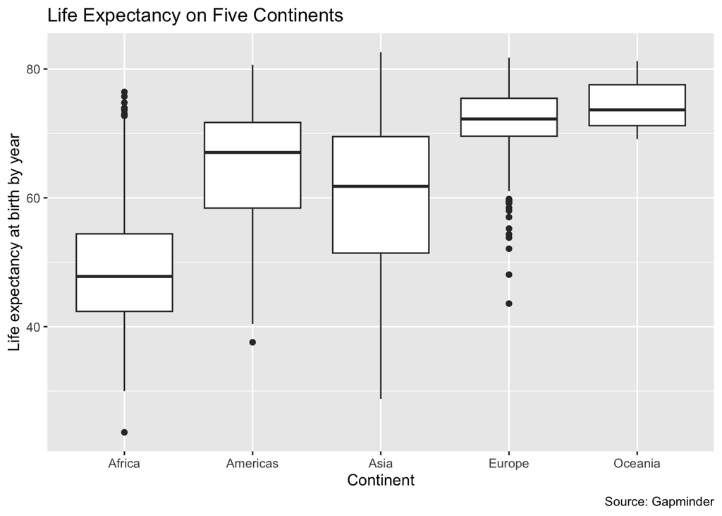

```r
require(ggplot2)
ggplot(data = gapminder, aes(x = continent, y = lifeExp)) +
  geom_boxplot() +
  labs(title = "Life Expectancy on Five Continents",
       x = "Continent", y = "Life expectancy at birth by year",
       caption = "Source: Gapminder")
```

### **Question 9 (5 points)**

Looking at the previous plot, which continent has the highest median life expectancy? Which part of the boxplot can we determine this from?

**Rubric**: 2 points for identifying the correct continent; 3 write-up points for correctly identifying how to find this on the boxplot.

### Solution:

Oceania seem to have the highest median life expectancy. This is determined by the horizontal line within the box, which represents the median value. The median line in the box for Oceania is at the highest position compared to the other continents, signifying that Oceania has the highest median life expectancy.